# Microbiome analysis of Germany and Sweden

Talia_Karasov

5/3/2019

# Load vs. microbiome composition

This script explores the relationship between load and microbiome for the german and swedish datasets and graphs the microbiomes of these datasets

## Overall Microbiome Comparison

The goal of this next part is to generate figures side-by-side that will take the metagenome corrected tables for germany and sweden and graph the bar plots next to one another

First thing is to remove the offending columns from the german dataset

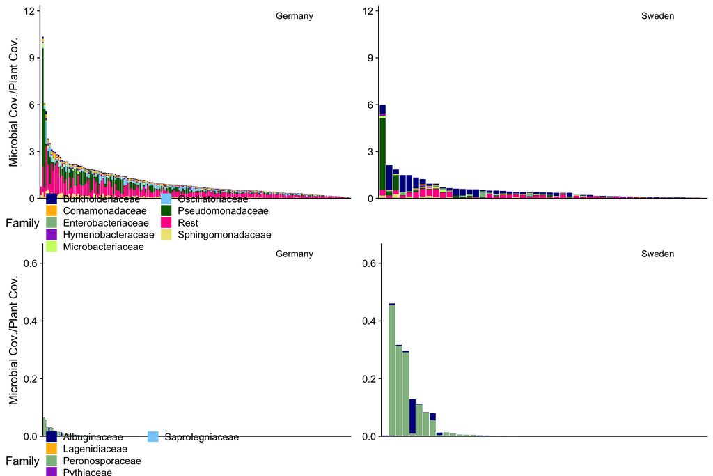

pdf(“~/Dropbox/controlled_metagenomics/results_figures/german_metagenome.pdf”, family = “ArialMT”) p <- ggplot(data=microb_melt, aes(x=Load, y=value, fill=Family)) p + geom_bar(aes(), stat=“identity”, position=“stack”) + scale_fill_manual(values = manual_colors) + theme(legend.position=“bottom”, panel.background = element_blank(), axis.line = element_line(colour = “black”), axis.text.x = element_blank()) + guides(fill=guide_legend(nrow=5)) + xlab(“Plant Individuals”) + ylab(“Microbial Cov./Plant Cov.”) + theme(axis.title.x=element_blank(),axis.text.x=element_blank(),axis.ticks.x=element_blank()) + scale_y_continuous(expand = c(0, 0), limits = c(0, 225))

dev.off()

pdf(“~/Dropbox/controlled_metagenomics/results_figures/germany_pseud_hpa.pdf”, family = “ArialMT”) families=data.frame(t(meta)) pseud=ggplot(data=families, aes(log10(Pseudomonadaceae))) + geom_histogram(fill=“GRAY”, colour = “BLACK”)+theme_bw()+xlab(expression(log[10]~(“Pseudomonadaceae coverage”/“Plant coverage”)))+geom_vline(aes(xintercept=-0.276, color=“Resistant”))+geom_vline(aes(xintercept=1.54, color=“Susceptible”)) hpa=ggplot(data=families, aes(log10(Peronosporaceae))) + geom_histogram(fill=“GRAY”, colour = “BLACK”)+theme_bw()+xlab(expression(log[10]~(“Peronosporaceae coverage”/“Plant coverage”)))+geom_vline(aes(xintercept=-1.146302, color=“Day 11”))+geom_vline(aes(xintercept=-2.518557 , color=“Day 5”)) grid.arrange(pseud, hpa, ncol=1) dev.off()

## Bacteria

First we will look at those reads classified as bacterial. We will perform principal coordinate analysis on the bray-curtis disimilarity to assess how load relates to similarity of microbiome content.

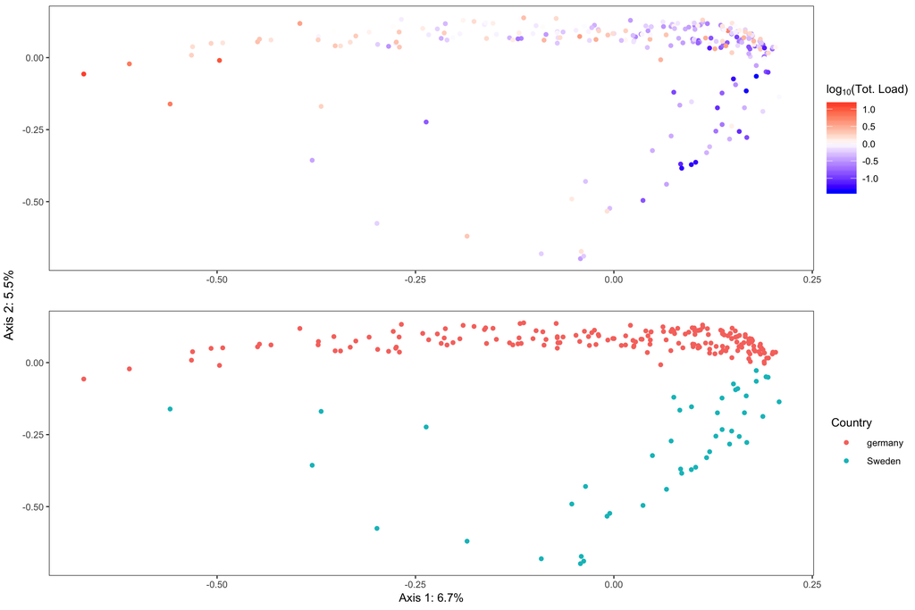

### Do PC1 and PC2 distinguish between samples from germany vs sweden?

First PC1:

```
##
##  Wilcoxon rank sum test with continuity correction
##
## data:  german_pc1 and sweden_pc1
## W = 3729, p-value = 0.1486
## alternative hypothesis: true location shift is not equal to 0
```

Next PC2:

```
##
##  Wilcoxon rank sum test with continuity correction
##
## data:  german_pc2 and sweden_pc2
## W = 8645, p-value < 2.2e-16
## alternative hypothesis: true location shift is not equal to 0
```

### What is the relationship between load and PC1?

```
##
##  Pearson's product-moment correlation
##
## data:  g_s_load and pc1
## t = -7.9609, df = 232, p-value = 7.579e-14
## alternative hypothesis: true correlation is not equal to 0
## 95 percent confidence interval:
##  -0.558286 -0.356113
## sample estimates:
##        cor
## -0.4632045
```

### How is load associated with Shannon Diversity

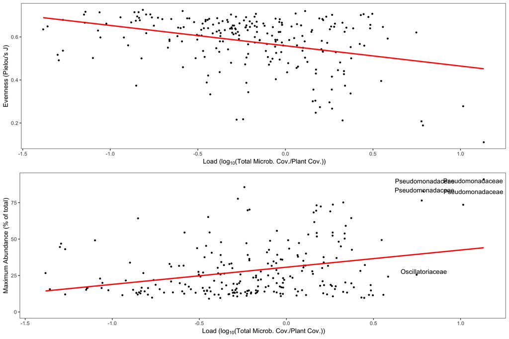

### Does load affect the overall evenness of the sample?

```
##
##  Pearson's product-moment correlation
##
## data:  g_s_load and J
## t = -7.1198, df = 232, p-value = 1.343e-11
## alternative hypothesis: true correlation is not equal to 0
## 95 percent confidence interval:
##  -0.5232858 -0.3121643
## sample estimates:
##        cor
## -0.4234577
```

```
##
##  Pearson's product-moment correlation
##
## data:  g_s_load and shannon_div
## t = -6.0511, df = 232, p-value = 5.724e-09
## alternative hypothesis: true correlation is not equal to 0
## 95 percent confidence interval:
##  -0.4749634 -0.2529368
## sample estimates:
##        cor
## -0.3692065
```

## Oomycetes

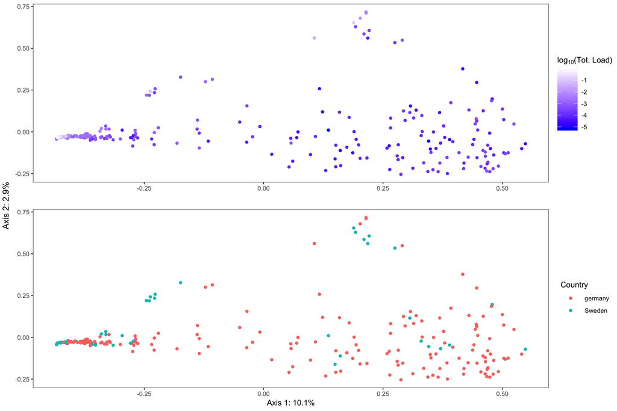

### Do PC1 and PC2 distinguish between samples from germany vs sweden?

First PC1:

```
##
##  Wilcoxon rank sum test with continuity correction
##
## data:  german_pc1 and sweden_pc1
## W = 5368, p-value = 0.005101
## alternative hypothesis: true location shift is not equal to 0
```

Next PC2:

```
##
##  Wilcoxon rank sum test with continuity correction
##
## data:  german_pc2 and sweden_pc2
## W = 3060, p-value = 0.003985
## alternative hypothesis: true location shift is not equal to 0
```

### What is the relationship between load and PC1?

```
##
##  Pearson's product-moment correlation
##
## data:  g_s_load and pc1
## t = -3.1033, df = 231, p-value = 0.002152
## alternative hypothesis: true correlation is not equal to 0
## 95 percent confidence interval:
##  -0.32034003 -0.07342122
## sample estimates:
##        cor
## -0.2000549
```

### How is load associated with Shannon Diversity

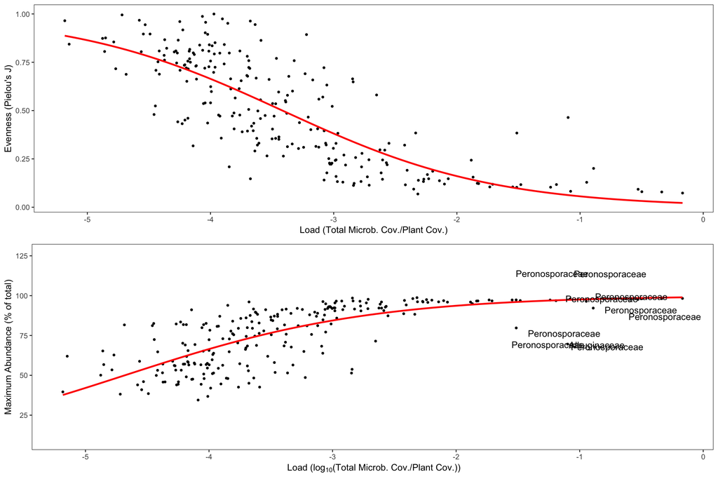

### Does load affect the overall evenness of the sample?

```
##
##  Pearson's product-moment correlation
##
## data:  g_s_load and J
## t = -4.1671, df = 231, p-value = 4.363e-05
## alternative hypothesis: true correlation is not equal to 0
## 95 percent confidence interval:
##  -0.3800218 -0.1406737
## sample estimates:
##        cor
## -0.2644146
```

```
##
##  Pearson's product-moment correlation
##
## data:  g_s_load and shannon_div
## t = -4.1498, df = 231, p-value = 4.68e-05
## alternative hypothesis: true correlation is not equal to 0
## 95 percent confidence interval:
##  -0.3790851 -0.1396007
## sample estimates:
##        cor
## -0.2633964
```

# Overall comparison of histograms